# Importing the packages and libraries that are required for the project

```python
import numpy as np
import pandas as pd
import matplotlib.pyplot as plt
from sklearn.model_selection import train_test_split, StratifiedKFold, GridSearchCV
from sklearn.neighbors import KNeighborsClassifier
from sklearn.ensemble import RandomForestClassifier
from sklearn.svm import SVC
import seaborn as sns
from sklearn.metrics import (
    roc_curve, auc, accuracy_score, precision_score, recall_score,
    f1_score, confusion_matrix, roc_auc_score, brier_score_loss
)
from keras.models import Sequential
from keras.layers import LSTM, Dense, Input
from sklearn.preprocessing import StandardScaler
```

# Loading Data

```python
# Default dataset path
default_path = "heart.csv"

# Ask user for dataset path or use default
file_path = input(f"Enter the path to the dataset (default: {default_path}): ") or default_path

# Load the dataset
data = pd.read_csv(file_path)

data = pd.read_csv("heart.csv")
data.head()
```

```
Enter the path to the dataset (default: heart.csv):
```

|  | age | anaemia | creatinine_phosphokinase | diabetes | ejection_fraction | high_blood_pressure | platelets | serum_creatinine | serum_sodium | sex | smoking | time | DEATH_EVENT |
| --- | --- | --- | --- | --- | --- | --- | --- | --- | --- | --- | --- | --- | --- |
| 0 | 75.0 | 0 | 582 | 0 | 20 | 1 | 265000.00 | 1.9 | 130 | 1 | 0 | 4 | 1 |
| 1 | 55.0 | 0 | 7861 | 0 | 38 | 0 | 263358.03 | 1.1 | 136 | 1 | 0 | 6 | 1 |
| 2 | 65.0 | 0 | 146 | 0 | 20 | 0 | 162000.00 | 1.3 | 129 | 1 | 1 | 7 | 1 |
| 3 | 50.0 | 1 | 111 | 0 | 20 | 0 | 210000.00 | 1.9 | 137 | 1 | 0 | 7 | 1 |
| 4 | 65.0 | 1 | 160 | 1 | 20 | 0 | 327000.00 | 2.7 | 116 | 0 | 0 | 8 | 1 |

```python
data.info()
```

```
<class 'pandas.core.frame.DataFrame'>
RangeIndex: 299 entries, 0 to 298
Data columns (total 13 columns):
 #   Column                    Non-Null Count  Dtype
---  ------                    --------------  -----
 0   age                       299 non-null    float64
 1   anaemia                   299 non-null    int64
 2   creatinine_phosphokinase  299 non-null    int64
 3   diabetes                  299 non-null    int64
 4   ejection_fraction         299 non-null    int64
 5   high_blood_pressure       299 non-null    int64
 6   platelets                 299 non-null    float64
 7   serum_creatinine          299 non-null    float64
 8   serum_sodium              299 non-null    int64
 9   sex                       299 non-null    int64
 10  smoking                   299 non-null    int64
 11  time                      299 non-null    int64
 12  DEATH_EVENT               299 non-null    int64
dtypes: float64(3), int64(10)
memory usage: 30.5 KB
```

# Evaluate Target Distribution

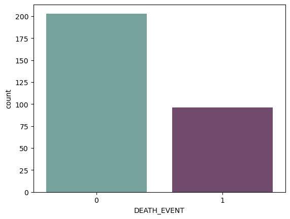

```python
#first of all let us evaluate the target and find out if our data is imbalanced or not
cols= ["#6daa9f","#774571"]
sns.countplot(x= data["DEATH_EVENT"], palette= cols)
```

# Correlation Matrix Analysis

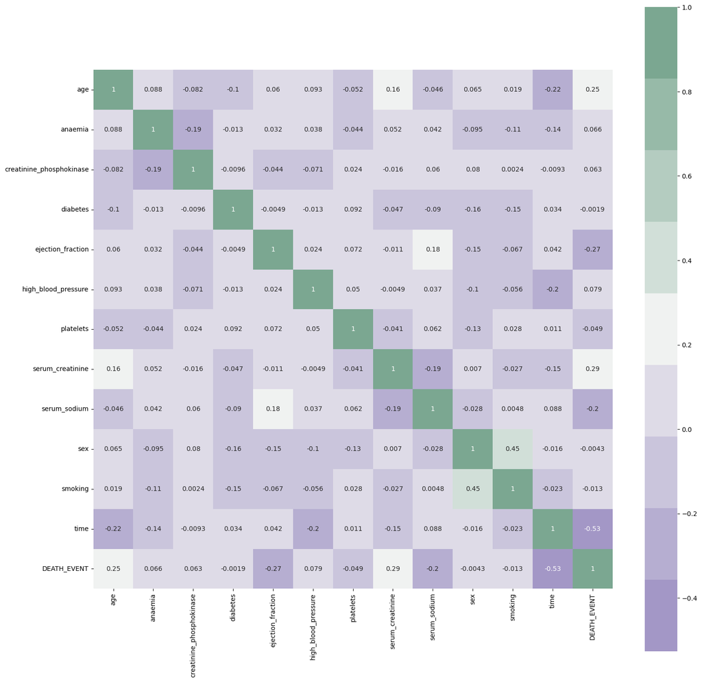

```python
#Examaning a corelation matrix of all the features
cmap = sns.diverging_palette(275,150,  s=40, l=65, n=9)
corrmat = data.corr()
plt.subplots(figsize=(18,18))
sns.heatmap(corrmat,cmap= cmap,annot=True, square=True);
```

# Age Distribution Visualization

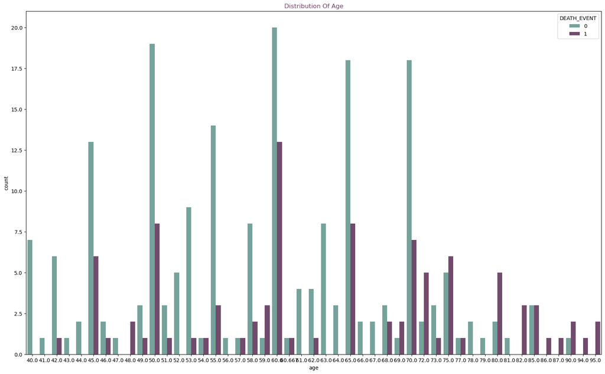

```python
#Evauating age distribution
plt.figure(figsize=(20,12))
#colours =["#774571","#b398af","#f1f1f1" ,"#afcdc7", "#6daa9f"]
Days_of_week=sns.countplot(x=data['age'],data=data, hue ="DEATH_EVENT",palette = cols)
Days_of_week.set_title("Distribution Of Age", color="#774571")
```

# Boxen and Swarm Plot Analysis

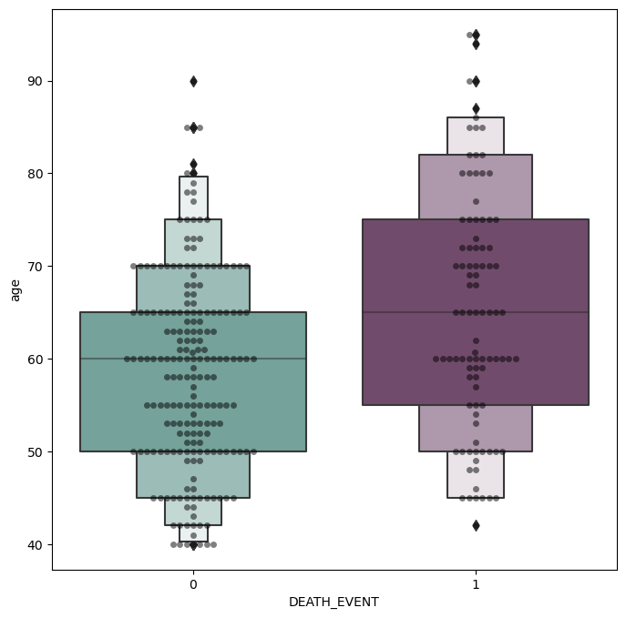

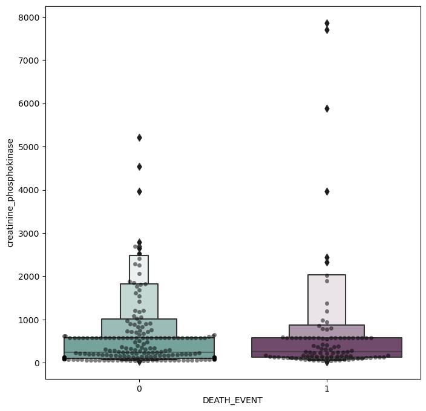

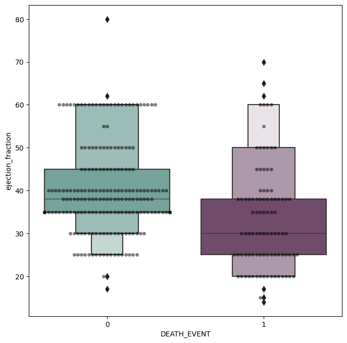

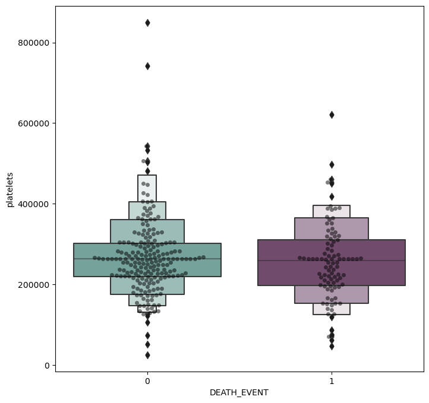

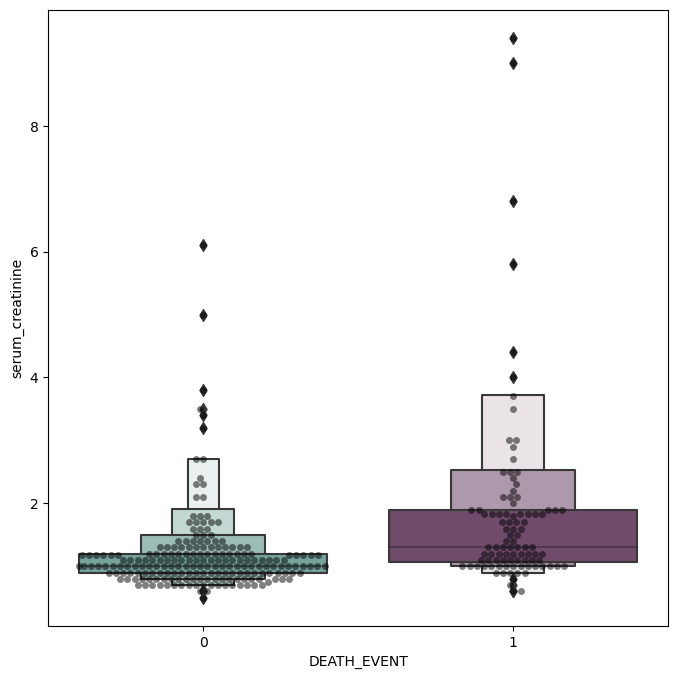

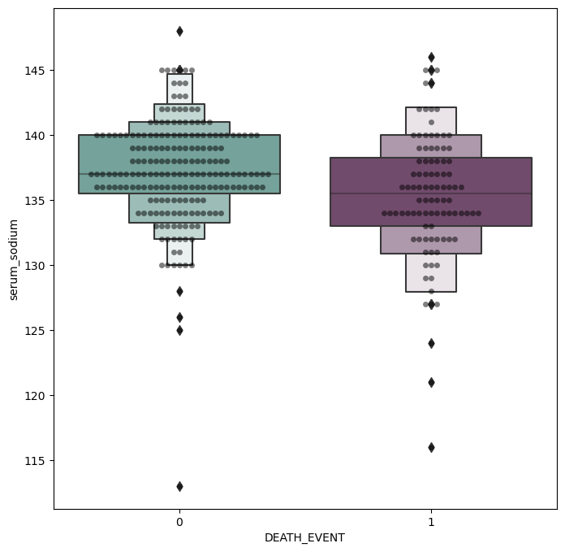

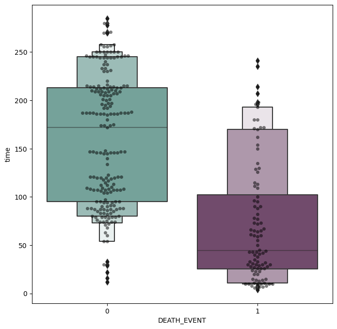

```python
# Boxen and swarm plot of some non binary features.
feature = ["age","creatinine_phosphokinase","ejection_fraction","platelets","serum_creatinine","serum_sodium", "time"]
for i in feature:
    plt.figure(figsize=(8,8))
    sns.swarmplot(x=data["DEATH_EVENT"], y=data[i], color="black", alpha=0.5)
    sns.boxenplot(x=data["DEATH_EVENT"], y=data[i], palette=cols)
    plt.show()
```

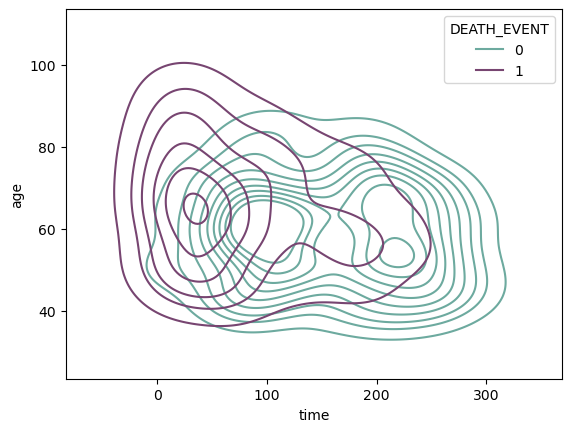

```python
sns.kdeplot(x=data["time"], y=data["age"], hue =data["DEATH_EVENT"], palette=cols)
```

```python
data.describe().T
```

|  | count | mean | std | min | 25% | 50% | 75% | max |
| --- | --- | --- | --- | --- | --- | --- | --- | --- |
| age | 299.0 | 60.833893 | 11.894809 | 40.0 | 51.0 | 60.0 | 70.0 | 95.0 |
| anaemia | 299.0 | 0.431438 | 0.496107 | 0.0 | 0.0 | 0.0 | 1.0 | 1.0 |
| creatinine_phosphokinase | 299.0 | 581.839465 | 970.287881 | 23.0 | 116.5 | 250.0 | 582.0 | 7861.0 |
| diabetes | 299.0 | 0.418060 | 0.494067 | 0.0 | 0.0 | 0.0 | 1.0 | 1.0 |
| ejection_fraction | 299.0 | 38.083612 | 11.834841 | 14.0 | 30.0 | 38.0 | 45.0 | 80.0 |
| high_blood_pressure | 299.0 | 0.351171 | 0.478136 | 0.0 | 0.0 | 0.0 | 1.0 | 1.0 |
| platelets | 299.0 | 263358.029264 | 97804.236869 | 25100.0 | 212500.0 | 262000.0 | 303500.0 | 850000.0 |
| serum_creatinine | 299.0 | 1.393880 | 1.034510 | 0.5 | 0.9 | 1.1 | 1.4 | 9.4 |
| serum_sodium | 299.0 | 136.625418 | 4.412477 | 113.0 | 134.0 | 137.0 | 140.0 | 148.0 |
| sex | 299.0 | 0.648829 | 0.478136 | 0.0 | 0.0 | 1.0 | 1.0 | 1.0 |
| smoking | 299.0 | 0.321070 | 0.467670 | 0.0 | 0.0 | 0.0 | 1.0 | 1.0 |
| time | 299.0 | 130.260870 | 77.614208 | 4.0 | 73.0 | 115.0 | 203.0 | 285.0 |
| DEATH_EVENT | 299.0 | 0.321070 | 0.467670 | 0.0 | 0.0 | 0.0 | 1.0 | 1.0 |

# Feature and Target Assignment

```python
#assigning values to features as X and target as y
X=data.drop(["DEATH_EVENT"],axis=1)
y=data["DEATH_EVENT"]
```

# Feature Scaling Setup

```python
#Set up a standard scaler for the features
# Set up a standard scaler for the features
col_names = list(X.columns)
s_scaler = StandardScaler()  # Directly use StandardScaler
X_df = s_scaler.fit_transform(X)
X_df = pd.DataFrame(X_df, columns=col_names)
X_df.describe().T
```

|  | count | mean | std | min | 25% | 50% | 75% | max |
| --- | --- | --- | --- | --- | --- | --- | --- | --- |
| age | 299.0 | 5.703353e-16 | 1.001676 | -1.754448 | -0.828124 | -0.070223 | 0.771889 | 2.877170 |
| anaemia | 299.0 | 1.009969e-16 | 1.001676 | -0.871105 | -0.871105 | -0.871105 | 1.147968 | 1.147968 |
| creatinine_phosphokinase | 299.0 | 0.000000e+00 | 1.001676 | -0.576918 | -0.480393 | -0.342574 | 0.000166 | 7.514640 |
| diabetes | 299.0 | 9.060014e-17 | 1.001676 | -0.847579 | -0.847579 | -0.847579 | 1.179830 | 1.179830 |
| ejection_fraction | 299.0 | -3.267546e-17 | 1.001676 | -2.038387 | -0.684180 | -0.007077 | 0.585389 | 3.547716 |
| high_blood_pressure | 299.0 | 0.000000e+00 | 1.001676 | -0.735688 | -0.735688 | -0.735688 | 1.359272 | 1.359272 |
| platelets | 299.0 | 7.723291e-17 | 1.001676 | -2.440155 | -0.520870 | -0.013908 | 0.411120 | 6.008180 |
| serum_creatinine | 299.0 | 1.425838e-16 | 1.001676 | -0.865509 | -0.478205 | -0.284552 | 0.005926 | 7.752020 |
| serum_sodium | 299.0 | -8.673849e-16 | 1.001676 | -5.363206 | -0.595996 | 0.085034 | 0.766064 | 2.582144 |
| sex | 299.0 | -8.911489e-18 | 1.001676 | -1.359272 | -1.359272 | 0.735688 | 0.735688 | 0.735688 |
| smoking | 299.0 | -1.188199e-17 | 1.001676 | -0.687682 | -0.687682 | -0.687682 | 1.454161 | 1.454161 |
| time | 299.0 | -1.901118e-16 | 1.001676 | -1.629502 | -0.739000 | -0.196954 | 0.938759 | 1.997038 |

# Train-Test Split and Standardization

```python
X_train, X_test, y_train, y_test = train_test_split(X, y, test_size=0.2, random_state=42)

# Standardize features
scaler = StandardScaler()
X_train_std = scaler.fit_transform(X_train)
X_test_std = scaler.transform(X_test)
```

# Manual Confusion Matrix Metrics Calculation

```python
# Function to calculate metrics from confusion matrix
def calc_metrics(confusion_matrix):
    TP, FN = confusion_matrix[0][0], confusion_matrix[0][1]
    FP, TN = confusion_matrix[1][0], confusion_matrix[1][1]
    TPR = TP / (TP + FN)
    TNR = TN / (TN + FP)
    FPR = FP / (TN + FP)
    FNR = FN / (TP + FN)
    Precision = TP / (TP + FP)
    F1_measure = 2 * TP / (2 * TP + FP + FN)
    Accuracy = (TP + TN) / (TP + FP + FN + TN)
    Error_rate = (FP + FN) / (TP + FP + FN + TN)
    BACC = (TPR + TNR) / 2
    TSS = TPR - FPR
    HSS = 2 * (TP * TN - FP * FN) / ((TP + FN) * (FN + TN) + (TP + FP) * (FP + TN))
    metrics = [TP, TN, FP, FN, TPR, TNR, FPR, FNR, Precision, F1_measure, Accuracy, Error_rate, BACC, TSS, HSS]
    return metrics
```

# Model Metrics Calculation Function

```python
# Function to fit model and calculate metrics
def get_metrics(model, X_train, X_test, y_train, y_test, LSTM_flag):
    metrics = []
    if LSTM_flag == 1:
        # Convert data to numpy array
        Xtrain, Xtest, ytrain, ytest = map(np.array, [X_train, X_test, y_train, y_test])
        # Reshape data
        shape = Xtrain.shape
        Xtrain_reshaped = Xtrain.reshape(len(Xtrain), shape[1], 1)
        Xtest_reshaped = Xtest.reshape(len(Xtest), shape[1], 1)
        model.fit(Xtrain_reshaped, ytrain, epochs=50, validation_data=(Xtest_reshaped, ytest), verbose=0)
        lstm_scores = model.evaluate(Xtest_reshaped, ytest, verbose=0)
        predict_prob = model.predict(Xtest_reshaped)
        pred_labels = predict_prob > 0.5
        pred_labels_1 = pred_labels.astype(int)
        matrix = confusion_matrix(ytest, pred_labels_1, labels=[1, 0])
        lstm_brier_score = brier_score_loss(ytest, predict_prob)
        lstm_roc_auc = roc_auc_score(ytest, predict_prob)
        metrics.extend(calc_metrics(matrix))
        metrics.extend([lstm_brier_score, lstm_roc_auc, lstm_scores[1]])
    elif LSTM_flag == 0:
        model.fit(X_train, y_train)
        predicted = model.predict(X_test)
        matrix = confusion_matrix(y_test, predicted, labels=[1, 0])
        model_brier_score = brier_score_loss(y_test, model.predict_proba(X_test)[:, 1])
        model_roc_auc = roc_auc_score(y_test, model.predict_proba(X_test)[:, 1])
        metrics.extend(calc_metrics(matrix))
        metrics.extend([model_brier_score, model_roc_auc, model.score(X_test, y_test)])
    return metrics
```

# Selecting Classification Algorithms

## Chosen Classification Algorithms

### * K-Nearest Neighbor (KNN)

### * Support Vector Machine (SVM)

## Selected Deep Learning Algorithm

### * Long Short-Term Memory (LSTM)

# Parameter Tuning for KNN

```python
# Define KNN parameters for grid search
knn_parameters = {"n_neighbors": [1, 2, 3, 4, 5, 6, 7, 8, 9, 10, 11, 12, 13, 14, 15]}

# Create KNN model
knn_model = KNeighborsClassifier()

# Perform grid search with cross-validation
knn_cv = GridSearchCV(knn_model, knn_parameters, cv=10, n_jobs=-1)

# Fit the model with training data
knn_cv.fit(X_train_std, y_train)

# Print the best parameters found by GridSearchCV
print("\nBest Parameters for KNN based on GridSearchCV: ", knn_cv.best_params_)
print()
```

```
Best Parameters for KNN based on GridSearchCV:  {'n_neighbors': 7}
```

```python
best_n_neighbors = knn_cv.best_params_['n_neighbors']
```

# Parameter Tuning for RandomForest

```python
# Define Random Forest parameters for grid search
param_grid_rf = {
    "n_estimators": [10, 20, 30, 40, 50, 60, 70, 80, 90, 100],
    "min_samples_split": [2, 4, 6, 8, 10],
}

# Create Random Forest model
rf_classifier = RandomForestClassifier(random_state=42)

# Perform grid search with cross-validation
grid_search_rf = GridSearchCV(estimator=rf_classifier, param_grid=param_grid_rf, cv=10, n_jobs=-1, scoring="accuracy")

# Fit the model with training data
grid_search_rf.fit(X_train_std, y_train)

# Display the best parameters from the grid search
best_rf_params = grid_search_rf.best_params_
print("\nBest Parameters for Random Forest based on GridSearchCV: ", best_rf_params)
print()

# Extract and print the best values for 'min_samples_split' and 'n_estimators'
best_min_samples_split = best_rf_params['min_samples_split']
best_n_estimators = best_rf_params['n_estimators']
print(f"Best 'min_samples_split': {best_min_samples_split}")
print(f"Best 'n_estimators': {best_n_estimators}")
```

```
Best Parameters for Random Forest based on GridSearchCV:  {'min_samples_split': 2, 'n_estimators': 70}

Best 'min_samples_split': 2
Best 'n_estimators': 70
```

# Parameter Tuning for SVM

```python
# Define Support Vector Machine parameters for grid search
param_grid_svc = {"kernel": ["linear"], "C": [1, 2, 3, 4, 5, 6, 7, 8, 9, 10]}

# Create Support Vector Machine model
svc_classifier = SVC()

# Perform grid search with cross-validation
grid_search_svc = GridSearchCV(estimator=svc_classifier, param_grid=param_grid_svc, cv=10, n_jobs=-1, scoring="accuracy")

# Fit the model with training data
grid_search_svc.fit(X_train_std, y_train)

# Display the best parameters from the grid search
best_svc_params = grid_search_svc.best_params_
print("\nBest Parameters for Support Vector Machine based on GridSearchCV: ", best_svc_params)
print()

# Extract and print the best value for 'C'
C_value = best_svc_params['C']
print(f"Best 'C' value: {C_value}")
```

```
Best Parameters for Support Vector Machine based on GridSearchCV:  {'C': 5, 'kernel': 'linear'}

Best 'C' value: 5
```

# 10-Fold Cross-Validation with Performance Metrics for KNN, Random Forest, SVM, and LSTM Models

```python
# Define Stratified K-Fold cross-validator
cv_stratified = StratifiedKFold(n_splits=10, shuffle=True, random_state=21)

# Initialize metric columns
metric_columns = [
    'TP', 'TN', 'FP', 'FN', 'TPR', 'TNR', 'FPR', 'FNR', 'Precision',
    'F1_measure', 'Accuracy', 'Error_rate', 'BACC', 'TSS', 'HSS',
    'Brier_score', 'AUC', 'Acc_by_package_fn'
]

# Initialize metrics lists for each algorithm
knn_metrics_list, rf_metrics_list, svm_metrics_list, lstm_metrics_list = [], [], [], []

# Placeholder for best parameters
best_n_neighbors = 3
min_samples_split = 4
n_estimators = 50
C = 1.0

# 10 Iterations of 10-fold cross-validation
for iter_num, (train_index, test_index) in enumerate(cv_stratified.split(X_train_std, y_train), start=1):
    # KNN Model
    knn_model = KNeighborsClassifier(n_neighbors=best_n_neighbors)

    # Random Forest Model
    rf_model = RandomForestClassifier(min_samples_split=min_samples_split, n_estimators=n_estimators, random_state=42)

    # SVM Classifier Model
    svm_model = SVC(C=C, kernel='linear', probability=True, random_state=42)

    # LSTM Model
    lstm_model = Sequential()
    lstm_model.add(Input(shape=(X_train_std.shape[1], 1)))
    lstm_model.add(LSTM(64, activation='relu', return_sequences=False))
    lstm_model.add(Dense(1, activation='sigmoid'))
    lstm_model.compile(loss='binary_crossentropy', optimizer='adam', metrics=['accuracy'])

    # Split data into training and testing sets
    features_train, features_test = X_train_std[train_index], X_train_std[test_index]
    labels_train, labels_test = y_train.iloc[train_index], y_train.iloc[test_index]

    # Reshape data for LSTM
    features_train_reshaped = features_train.reshape(features_train.shape[0], features_train.shape[1], 1)
    features_test_reshaped = features_test.reshape(features_test.shape[0], features_test.shape[1], 1)

    # Get metrics for each algorithm
    knn_metrics = get_metrics(knn_model, features_train, features_test, labels_train, labels_test, LSTM_flag=0)
    rf_metrics = get_metrics(rf_model, features_train, features_test, labels_train, labels_test, LSTM_flag=0)
    svm_metrics = get_metrics(svm_model, features_train, features_test, labels_train, labels_test, LSTM_flag=0)
    lstm_metrics = get_metrics(lstm_model, features_train_reshaped, features_test_reshaped, labels_train, labels_test, LSTM_flag=1)

    # Append metrics to respective lists
    knn_metrics_list.append(knn_metrics)
    rf_metrics_list.append(rf_metrics)
    svm_metrics_list.append(svm_metrics)
    lstm_metrics_list.append(lstm_metrics)

    # Create a DataFrame for all metrics
    metrics_all_df = pd.DataFrame(
        [knn_metrics, rf_metrics, svm_metrics, lstm_metrics],
        columns=metric_columns,
        index=['KNN', 'RF', 'SVM', 'LSTM']
    )

    # Display metrics for all algorithms in each iteration
    print(f'\nIteration {iter_num}: \n')
    print(f'\n----- Metrics for all Algorithms in Iteration {iter_num} -----\n')
    print(metrics_all_df.round(decimals=2).T)
    print('\n')
```

```
1/1 ━━━━━━━━━━━━━━━━━━━━ 0s 43ms/step

Iteration 1:


----- Metrics for all Algorithms in Iteration 1 -----

                     KNN     RF    SVM   LSTM
TP                  2.00   6.00   7.00   7.00
TN                 15.00  15.00  13.00  13.00
FP                  1.00   1.00   3.00   3.00
FN                  6.00   2.00   1.00   1.00
TPR                 0.25   0.75   0.88   0.88
TNR                 0.94   0.94   0.81   0.81
FPR                 0.06   0.06   0.19   0.19
FNR                 0.75   0.25   0.12   0.12
Precision           0.67   0.86   0.70   0.70
F1_measure          0.36   0.80   0.78   0.78
Accuracy            0.71   0.88   0.83   0.83
Error_rate          0.29   0.12   0.17   0.17
BACC                0.59   0.84   0.84   0.84
TSS                 0.19   0.69   0.69   0.69
HSS                 0.22   0.71   0.65   0.65
Brier_score         0.20   0.13   0.11   0.14
AUC                 0.74   0.89   0.92   0.90
Acc_by_package_fn   0.71   0.88   0.83   0.83


1/1 ━━━━━━━━━━━━━━━━━━━━ 0s 42ms/step

Iteration 2:


----- Metrics for all Algorithms in Iteration 2 -----

                     KNN     RF    SVM   LSTM
TP                  4.00   6.00   5.00   5.00
TN                 16.00  16.00  16.00  15.00
FP                  1.00   1.00   1.00   2.00
FN                  3.00   1.00   2.00   2.00
```

[output cut: 225 more lines]

```
FN                  4.00   2.00   3.00   4.00
TPR                 0.43   0.71   0.57   0.43
TNR                 0.88   1.00   0.94   0.94
FPR                 0.12   0.00   0.06   0.06
FNR                 0.57   0.29   0.43   0.57
Precision           0.60   1.00   0.80   0.75
F1_measure          0.50   0.83   0.67   0.55
Accuracy            0.74   0.91   0.83   0.78
Error_rate          0.26   0.09   0.17   0.22
BACC                0.65   0.86   0.75   0.68
TSS                 0.30   0.71   0.51   0.37
HSS                 0.33   0.78   0.55   0.42
Brier_score         0.22   0.11   0.15   0.16
AUC                 0.65   0.93   0.84   0.77
Acc_by_package_fn   0.74   0.91   0.83   0.78
```

# Generate and Display Metrics DataFrames for KNN, Random Forest, SVM, and LSTM Across Iterations

```python
# Initialize metric index for each iteration
metric_index_df = ['iter1', 'iter2', 'iter3', 'iter4', 'iter5', 'iter6', 'iter7', 'iter8', 'iter9', 'iter10']

# Create DataFrames for each algorithm's metrics
knn_metrics_df = pd.DataFrame(knn_metrics_list, columns=metric_columns, index=metric_index_df)
rf_metrics_df = pd.DataFrame(rf_metrics_list, columns=metric_columns, index=metric_index_df)
svm_metrics_df = pd.DataFrame(svm_metrics_list, columns=metric_columns, index=metric_index_df)
lstm_metrics_df = pd.DataFrame(lstm_metrics_list, columns=metric_columns, index=metric_index_df)

# Display metrics for each algorithm in each iteration
for i, (name, metrics_df) in enumerate(
    zip(["KNN", "Random Forest", "SVM", "LSTM"], [knn_metrics_df, rf_metrics_df, svm_metrics_df, lstm_metrics_df]), start=1
):
    print(f'\nMetrics for Algorithm {name}:\n')
    print(metrics_df.round(decimals=2).T)
    print('\n')
```

```
Metrics for Algorithm KNN:

                   iter1  iter2  iter3  iter4  iter5  iter6  iter7  iter8  \
TP                  2.00   4.00   3.00   4.00   1.00   2.00   2.00   2.00
TN                 15.00  16.00  14.00  16.00  16.00  14.00  15.00  16.00
FP                  1.00   1.00   3.00   1.00   1.00   3.00   2.00   1.00
FN                  6.00   3.00   4.00   3.00   6.00   5.00   5.00   5.00
TPR                 0.25   0.57   0.43   0.57   0.14   0.29   0.29   0.29
TNR                 0.94   0.94   0.82   0.94   0.94   0.82   0.88   0.94
FPR                 0.06   0.06   0.18   0.06   0.06   0.18   0.12   0.06
FNR                 0.75   0.43   0.57   0.43   0.86   0.71   0.71   0.71
Precision           0.67   0.80   0.50   0.80   0.50   0.40   0.50   0.67
F1_measure          0.36   0.67   0.46   0.67   0.22   0.33   0.36   0.40
Accuracy            0.71   0.83   0.71   0.83   0.71   0.67   0.71   0.75
Error_rate          0.29   0.17   0.29   0.17   0.29   0.33   0.29   0.25
BACC                0.59   0.76   0.63   0.76   0.54   0.55   0.58   0.61
TSS                 0.19   0.51   0.25   0.51   0.08   0.11   0.17   0.23
HSS                 0.22   0.56   0.26   0.56   0.11   0.12   0.19   0.27
Brier_score         0.20   0.15   0.23   0.11   0.24   0.28   0.19   0.21
AUC                 0.74   0.85   0.66   0.90   0.57   0.49   0.73   0.66
Acc_by_package_fn   0.71   0.83   0.71   0.83   0.71   0.67   0.71   0.75

                   iter9  iter10
TP                  1.00    3.00
TN                 14.00   14.00
FP                  3.00    2.00
FN                  6.00    4.00
TPR                 0.14    0.43
TNR                 0.82    0.88
FPR                 0.18    0.12
FNR                 0.86    0.57
Precision           0.25    0.60
F1_measure          0.18    0.50
Accuracy            0.62    0.74
Error_rate          0.38    0.26
BACC                0.48    0.65
TSS                -0.03    0.30
HSS                -0.04    0.33
Brier_score         0.24    0.22
AUC                 0.55    0.65
```

[output cut: 118 more lines]

```
FN                  1.00    4.00
TPR                 0.86    0.43
TNR                 0.88    0.94
FPR                 0.12    0.06
FNR                 0.14    0.57
Precision           0.75    0.75
F1_measure          0.80    0.55
Accuracy            0.88    0.78
Error_rate          0.12    0.22
BACC                0.87    0.68
TSS                 0.74    0.37
HSS                 0.71    0.42
Brier_score         0.13    0.16
AUC                 0.92    0.77
Acc_by_package_fn   0.88    0.78
```

# Calculate the average metrics for each algorithm

```python
knn_avg_df = knn_metrics_df.mean()
rf_avg_df = rf_metrics_df.mean()
svm_avg_df = svm_metrics_df.mean()
lstm_avg_df = lstm_metrics_df.mean()

# Create a DataFrame with the average performance for each algorithm
avg_performance_df = pd.DataFrame({
    'KNN': knn_avg_df,
    'RF': rf_avg_df,
    'SVM': svm_avg_df,
    'LSTM': lstm_avg_df
}, index=metric_columns)

# Display the average performance for each algorithm
print("\nAverage Performance Metrics for Each Algorithm:\n")
print(avg_performance_df.round(decimals=2))
```

```
Average Performance Metrics for Each Algorithm:

                     KNN     RF    SVM   LSTM
TP                  2.40   5.70   5.10   4.70
TN                 15.00  15.50  14.70  15.60
FP                  1.80   1.30   2.10   1.20
FN                  4.70   1.40   2.00   2.40
TPR                 0.34   0.80   0.72   0.66
TNR                 0.89   0.92   0.88   0.93
FPR                 0.11   0.08   0.12   0.07
FNR                 0.66   0.20   0.28   0.34
Precision           0.57   0.83   0.72   0.82
F1_measure          0.42   0.81   0.71   0.71
Accuracy            0.73   0.89   0.83   0.85
Error_rate          0.27   0.11   0.17   0.15
BACC                0.62   0.86   0.80   0.79
TSS                 0.23   0.73   0.59   0.59
HSS                 0.26   0.73   0.59   0.61
Brier_score         0.21   0.10   0.12   0.13
AUC                 0.68   0.92   0.90   0.86
Acc_by_package_fn   0.73   0.89   0.83   0.85
```

# Evaluating the performance of various algorithms by comparing their ROC curves and AUC scores on the test dataset

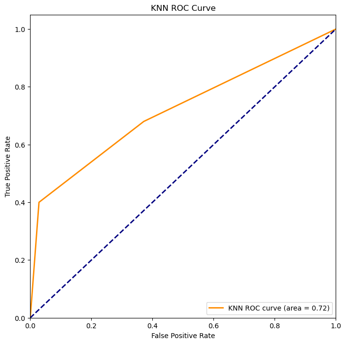

```python
# Evaluate KNN
knn_model = KNeighborsClassifier(n_neighbors=best_n_neighbors)
knn_model.fit(X_train_std, y_train)
y_score_knn = knn_model.predict_proba(X_test_std)[:, 1]

# Compute ROC curve and ROC area
fpr_knn, tpr_knn, _ = roc_curve(y_test, y_score_knn)
roc_auc_knn = auc(fpr_knn, tpr_knn)

# Plot ROC curve
plt.figure(figsize=(8, 8))
plt.plot(fpr_knn, tpr_knn, color='darkorange', lw=2, label='KNN ROC curve (area = {:.2f})'.format(roc_auc_knn))
plt.plot([0, 1], [0, 1], color='navy', lw=2, linestyle='--')
plt.xlim([0.0, 1.0])
plt.ylim([0.0, 1.05])
plt.xlabel('False Positive Rate')
plt.ylabel('True Positive Rate')
plt.title('KNN ROC Curve')
plt.legend(loc='lower right')
plt.show()
```

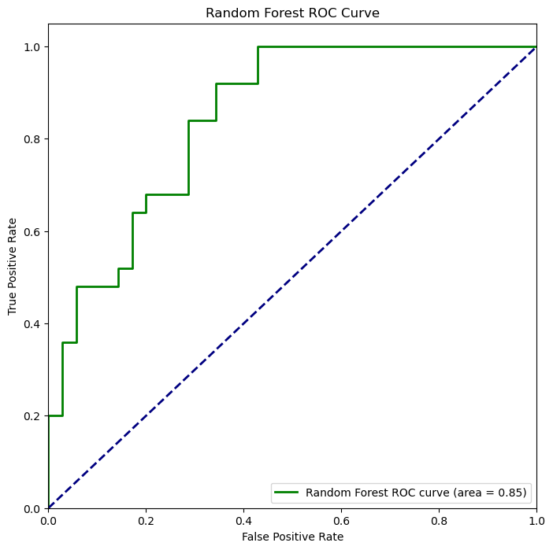

```python
# Evaluate Random Forest
rf_model = RandomForestClassifier(n_estimators=n_estimators, min_samples_split=min_samples_split, random_state=42)
rf_model.fit(X_train_std, y_train)
y_score_rf = rf_model.predict_proba(X_test_std)[:, 1]

# Compute ROC curve and ROC area
fpr_rf, tpr_rf, _ = roc_curve(y_test, y_score_rf)
roc_auc_rf = auc(fpr_rf, tpr_rf)

# Plot ROC curve
plt.figure(figsize=(8, 8))
plt.plot(fpr_rf, tpr_rf, color='green', lw=2, label='Random Forest ROC curve (area = {:.2f})'.format(roc_auc_rf))
plt.plot([0, 1], [0, 1], color='navy', lw=2, linestyle='--')
plt.xlim([0.0, 1.0])
plt.ylim([0.0, 1.05])
plt.xlabel('False Positive Rate')
plt.ylabel('True Positive Rate')
plt.title('Random Forest ROC Curve')
plt.legend(loc='lower right')
plt.show()
```

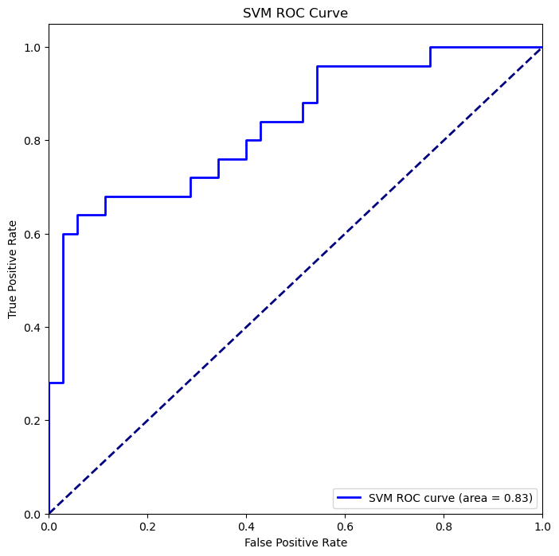

```python
# Evaluate SVM
svm_model = SVC(C=C, kernel='linear', probability=True, random_state=42)
svm_model.fit(X_train_std, y_train)
y_score_svm = svm_model.predict_proba(X_test_std)[:, 1]

# Compute ROC curve and ROC area
fpr_svm, tpr_svm, _ = roc_curve(y_test, y_score_svm)
roc_auc_svm = auc(fpr_svm, tpr_svm)

# Plot ROC curve
plt.figure(figsize=(8, 8))
plt.plot(fpr_svm, tpr_svm, color='blue', lw=2, label='SVM ROC curve (area = {:.2f})'.format(roc_auc_svm))
plt.plot([0, 1], [0, 1], color='navy', lw=2, linestyle='--')
plt.xlim([0.0, 1.0])
plt.ylim([0.0, 1.05])
plt.xlabel('False Positive Rate')
plt.ylabel('True Positive Rate')
plt.title('SVM ROC Curve')
plt.legend(loc='lower right')
plt.show()
```

```
2/2 ━━━━━━━━━━━━━━━━━━━━ 0s 2ms/step
```

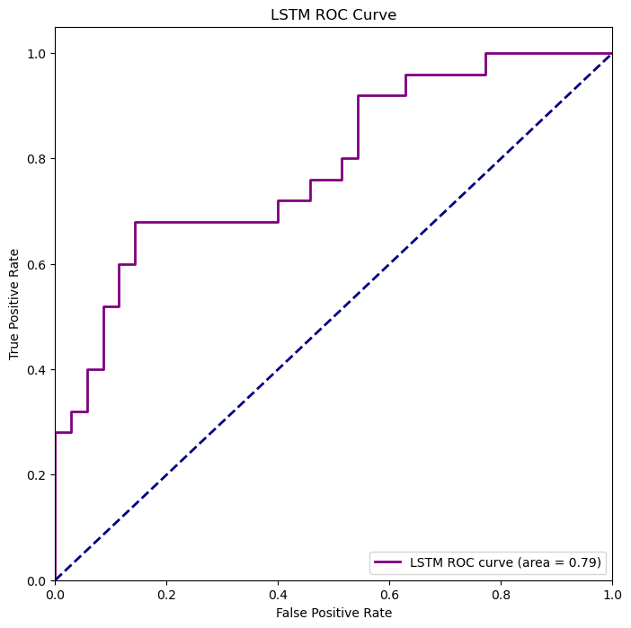

```python
# Evaluate LSTM

# Reshape test data for LSTM
features_test_reshaped = X_test_std.reshape(X_test_std.shape[0], X_test_std.shape[1], 1)

# Predicted probabilities
y_score_lstm = lstm_model.predict(features_test_reshaped)

# Compute ROC curve and ROC area
fpr_lstm, tpr_lstm, _ = roc_curve(y_test, y_score_lstm)
roc_auc_lstm = auc(fpr_lstm, tpr_lstm)

# Plot ROC curve
plt.figure(figsize=(8, 8))
plt.plot(fpr_lstm, tpr_lstm, color='purple', lw=2, label='LSTM ROC curve (area = {:.2f})'.format(roc_auc_lstm))
plt.plot([0, 1], [0, 1], color='navy', lw=2, linestyle='--')
plt.xlim([0.0, 1.0])
plt.ylim([0.0, 1.05])
plt.xlabel('False Positive Rate')
plt.ylabel('True Positive Rate')
plt.title('LSTM ROC Curve')
plt.legend(loc='lower right')
plt.show()
```

```python
# Print the average performance metrics for each algorithm
print("\nAverage Performance Metrics for Each Algorithm:\n")
print(avg_performance_df.round(decimals=2))
print('\n')
```

```
Average Performance Metrics for Each Algorithm:

                     KNN     RF    SVM   LSTM
TP                  2.40   5.70   5.10   4.70
TN                 15.00  15.50  14.70  15.60
FP                  1.80   1.30   2.10   1.20
FN                  4.70   1.40   2.00   2.40
TPR                 0.34   0.80   0.72   0.66
TNR                 0.89   0.92   0.88   0.93
FPR                 0.11   0.08   0.12   0.07
FNR                 0.66   0.20   0.28   0.34
Precision           0.57   0.83   0.72   0.82
F1_measure          0.42   0.81   0.71   0.71
Accuracy            0.73   0.89   0.83   0.85
Error_rate          0.27   0.11   0.17   0.15
BACC                0.62   0.86   0.80   0.79
TSS                 0.23   0.73   0.59   0.59
HSS                 0.26   0.73   0.59   0.61
Brier_score         0.21   0.10   0.12   0.13
AUC                 0.68   0.92   0.90   0.86
Acc_by_package_fn   0.73   0.89   0.83   0.85
```

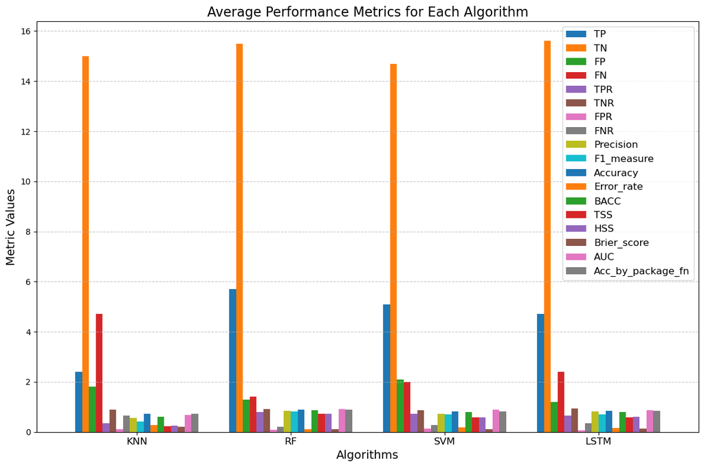

```python
# Plot bar chart for average metrics
avg_performance_df.T.plot(kind='bar', figsize=(12, 8), width=0.8)

# Add labels and title
plt.title('Average Performance Metrics for Each Algorithm', fontsize=16)
plt.ylabel('Metric Values', fontsize=14)
plt.xlabel('Algorithms', fontsize=14)
plt.xticks(rotation=0, fontsize=12)
plt.legend(loc='upper right', fontsize=12)
plt.grid(axis='y', linestyle='--', alpha=0.7)

# Show the plot
plt.tight_layout()
plt.show()
```

In this project, we tested different algorithms to predict heart disease outcomes using patient data. The models we used were:

K-Nearest Neighbors (KNN) Random Forest (RF) Support Vector Machine (SVM) Long Short-Term Memory (LSTM)

Best-Performing Algorithm: Random Forest Random Forest gave the best results compared to the other models. It performed well in terms of accuracy, precision, and recall. Here’s why:

Handles Complex Data: Random Forest can handle complex relationships in the data better than many other algorithms.

Avoids Overfitting: By using multiple decision trees, Random Forest makes predictions that are more balanced and reliable.

Why Not Other Algorithms?

KNN: It didn’t perform as well because it’s sensitive to outliers and high-dimensional data. SVM: While it gave good results, it required more time and tuning to work properly. LSTM: This deep learning model needs more data to perform its best. It works better for time-series data than the kind used here.

Random Forest was the best choice for this project because it gave accurate results and worked well with the data we had.